# Machine Learning

vivi

20 gennaio 2019

## Synopsis and Executive Summary

Using devices such as Jawbone Up, Nike FuelBand, and Fitbit it is now possible to collect a large amount of data about personal activity. In this project; the data set is taken from accelerometers on the belt, forearm, arm, and dumbell of 6 participants. They were asked to perform barbell lifts correctly and incorrectly in 5 different ways. http://web.archive.org/web/20161224072740/http:/groupware.les.inf.puc-rio.br/har. The goal is to qualify how well they do it.

### Data Exploration and Processing

Datataset is composed by 19622 observation vs 160 variable

```r
setwd("~/script_vecchi_coursera/machine_learning/data")
train <- read.csv("pml-training.csv",na.strings = c("NA",""))
print("Size of the dataset:")
```

```
## [1] "Size of the dataset:"
```

```r
dim(train)
```

```
## [1] 19622   160
```

## Data Cleaning

I select only the variable that are numeric and don’t contain NA

```
## [1] "Size of the dataset:"
```

```
## [1] 19622    53
```

The data set is split in traing (75%) and valdation (25%) set

```r
## Split the train set
tmp<-createDataPartition(train$classe,p=0.75,list = FALSE)
train_data<-train[tmp,]
valid_data<-train[-tmp,]
rm(url,url1,work_dir,test_name,train,tmp)
```

## Data exploration

Plot the correlation matrix of the training data set.

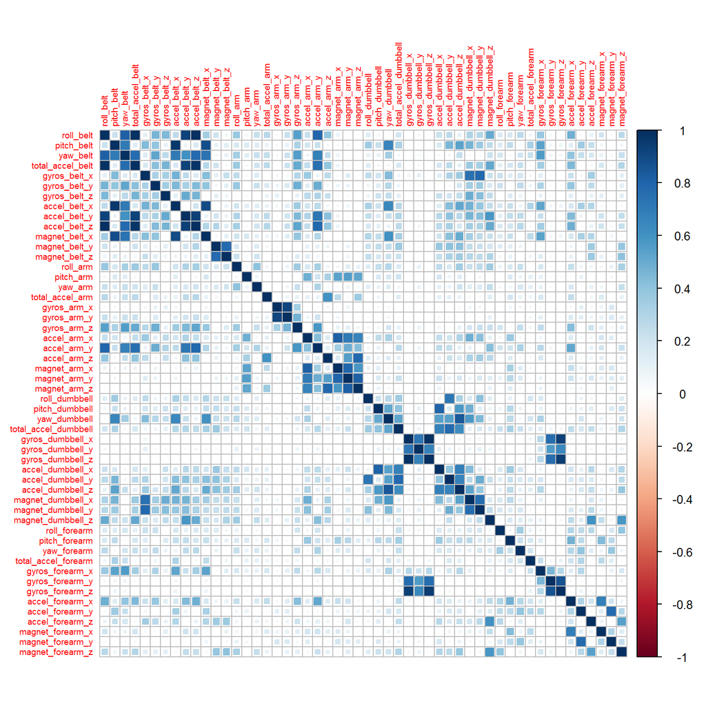

By inspection of the plot are evidnet tha variable that are correlated. PCA preprocessing, seem like to be a good option and also reduce the number of variable used to run the model.

99% of the variation is captured by 36 PC and there is a 32% reduction in the size of dateset.

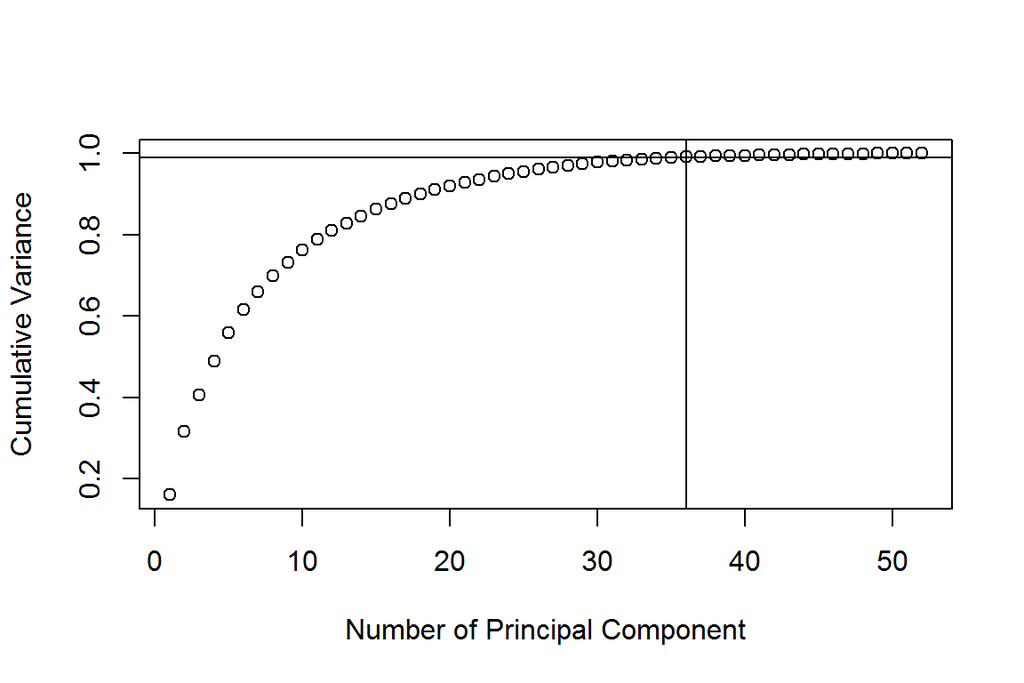

```
## [1] "Varaince captured by 36 PC"
```

```
## [1] 0.9909027
```

## Model Building

For model building, Random Forest algoritm is used over the data set preprocessed using PCA. doMParallel is used to parallelize the model creation.

```r
gc() #garbage colletor
```

```
##           used (Mb) gc trigger  (Mb) max used  (Mb)
## Ncells 1968056 60.1    3886987 118.7  2503534  76.5
## Vcells 3042261 23.3   13870978 105.9 13866851 105.8
```

```r
library(doParallel)
cl <- makePSOCKcluster(4)
registerDoParallel(cl)

model<-randomForest(classe ~ .,data = train_PCA,method = "rf")

stopCluster(cl)

valid_RF<-predict(model,newdata=valid_PCA)

confusionMatrix(valid_RF,valid_PCA$classe)
```

```
## Confusion Matrix and Statistics
##
##           Reference
## Prediction    A    B    C    D    E
##          A 1389   22    0    2    1
##          B    4  915   11    0    4
##          C    1    9  840   32    3
##          D    1    0    4  766    2
##          E    0    3    0    4  891
##
## Overall Statistics
##
##                Accuracy : 0.979
##                  95% CI : (0.9746, 0.9828)
##     No Information Rate : 0.2845
##     P-Value [Acc > NIR] : < 2.2e-16
##
##                   Kappa : 0.9734
##  Mcnemar's Test P-Value : NA
##
## Statistics by Class:
##
##                      Class: A Class: B Class: C Class: D Class: E
## Sensitivity            0.9957   0.9642   0.9825   0.9527   0.9889
## Specificity            0.9929   0.9952   0.9889   0.9983   0.9983
## Pos Pred Value         0.9823   0.9797   0.9492   0.9909   0.9922
## Neg Pred Value         0.9983   0.9914   0.9963   0.9908   0.9975
## Prevalence             0.2845   0.1935   0.1743   0.1639   0.1837
## Detection Rate         0.2832   0.1866   0.1713   0.1562   0.1817
## Detection Prevalence   0.2883   0.1905   0.1805   0.1576   0.1831
## Balanced Accuracy      0.9943   0.9797   0.9857   0.9755   0.9936
```

## Model to test data

Test data is cleaned and preprocessed has before. PCA is applied using the preprocessing model built on training data. The random forest model built on the training data is then applied on the test data to yield the results.

```r
#final
setwd("~/script_vecchi_coursera/machine_learning/data")
test <- read.csv("pml-testing.csv",na.strings = c("NA",""))
tmp<-colSums(is.na(test))
test<-test[,tmp==0]
test<-test[,-c(1:7)]
dim(test)
```

```
## [1] 20 53
```

```r
test_PCA<-predict(PCA_Comp,test)
predict_test<-predict(model,test_PCA)
predict_test
```

```
##  1  2  3  4  5  6  7  8  9 10 11 12 13 14 15 16 17 18 19 20
##  B  A  B  A  A  E  D  B  A  A  B  C  B  A  E  E  A  B  B  B
## Levels: A B C D E
```